# Introdução a Títulos de Dívida

Ross et al. (2022), capítulo 07

Marcelo S. Perlin

EA-UFRGS

15/09/2026

# Introdução a contratos de dívidas

## Introdução

> Títulos de dívida são contratos financeiros de troca de fluxos de caixa no tempo entre duas partes, o devedor e o credor
- Tipo de contrato mais simples e mais popular
- Para a empresa, uma dívida possui benefício fiscal e permite que novos lucros não sejam divididos com novos acionistas
  - Os juros, porém, podem deixar a empresa em posição financeira muito ruim
- Importância das dívidas para a Economia:
  - Em 01/12/2025, o total da [dívida líquida do setor público](https://dadosabertos.bcb.gov.br/dataset/4505-divida-liquida-do-setor-publico--pib---total---banco-central), incluindo governo federal e estados, é de **R$ 8.101.826.200.000,00**

## Pergunta

> Um amigo *médio* de vocês pediu para tomar R$ 2.500,00 hoje, com pagamento da dívida em um ano.
- Quais os pontos que vocês analisam antes de tomar a dívida?
- Quanto voces cobrariam?

# Componentes de um título de renda fixa

## Quais os elementos do contrato?

**Valor de face**

Valor nominal de pagamento no final/expiração do contrato

**Cupom (nominal ou percentual)**

Define os pagamentos intermediários, geralmente semestrais. Para chegar no valor nominal, multiplique o cupom percentual pelo valor de face.

**Maturidade**

Data fixa de vencimento do contrato de dívida. Define o tempo da dívida.

**Risco de *default**

Probabilidade de não pagamento da dívida e evento de *default*.

# Tipos de dívidas

## Tipos de títulos (forma de pagamento)

- **Títulos prefixados com (ou sem) pagamento de cupons**
  - O valor de face e os cupoms são pré-definidos
  - Quando cupons não existem, o comprador somente recebe o principal (valor de face).
    - Exemplo: Tesouro Prefixado 2021 (LTN), CDB de banco
- **Títulos pós fixados com (ou sem) pagamento de cupons**
  - Valores de face e cupons são vinculados a:
    - Inflação: IPCA (Índice nacional de preços ao consumidor amplo) ou IGP-M,- Índice Geral de preços do mercado
    - Juros: Taxa Selic – Taxa de retorno praticada entre o Banco Central do Brasil e os demais bancos. Exemplo: Tesouro Selic 2021 (LFT), Tesouro IPCA+ 2019 (NTNB Princ)

## Representação de um Título de Renda Fixa **SEM** Cupons

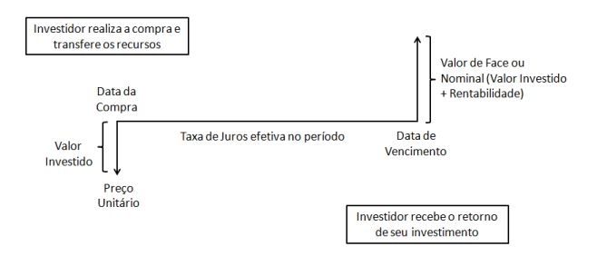

Exemplo de título de dívida sem cupom (fonte: [site TD](https://www.tesourodireto.com.br/titulos/tipos-de-tesouro.htm) )

## Representação de um Título de Renda Fixa **COM** Cupons

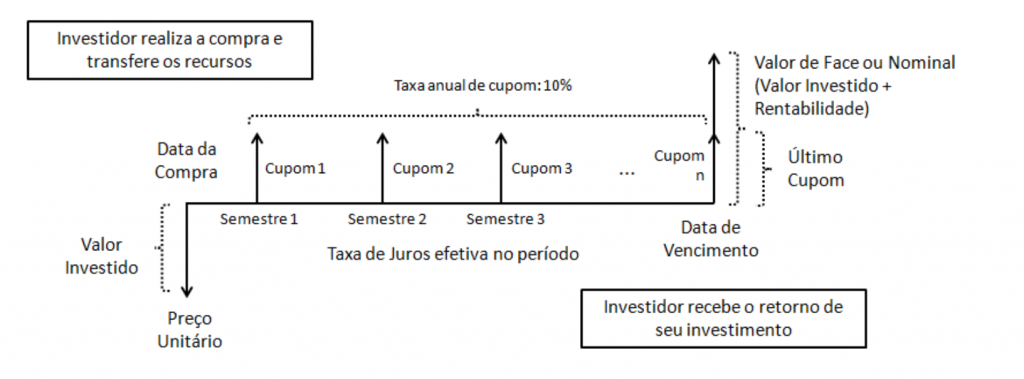

# Tipos de Emissores

## Possíveis emissores de dívidas

- **Título Públicos**
  - LTN - Letras do Tesouro Nacional (Tesouro Prefixado)
  - LFT - Letras Financeiras do Tesouro (Tesouro Selic)
  - NTN-B - Notas do Tesouro Nacional (Tesouro IPCA)
  - NTN-B1 - Renda+
- **Títulos Privados**
  - Debêntures (longo prazo, maior do que 1 ano)
  - Notas promissórias (curto prazo, menores do que 1 ano)

## Risco de uma dívida

> O risco de uma dívida é relativo as chances de não pagamento dos cupons ou valor principal.
- Quanto maior a incerteza, maior o risco
  - O risco dos títulos públicos é sempre menor que o risco de títulos privados
  - O risco aumenta com a duração (maturidade) da dívida
- É prática de mercado cobrar o máximo, o mais antecipado possível (famosa tabela SAC no financiamento imobiliário).

# Tesouro Direto

## O Sistema do Tesouro Direto

> Sistema criado na parceria entre Bovespa (B3) e Tesouro nacional em 2002 para permitir a compra de títulos de dívida pública para a pessoa física
- Oferece contratos de dívida com **remuneração** e **liquidez** atraentes
- Do ponto de vista do governo é uma nova fonte de obtenção de recursos, além de instrumento de política econômica
- Características:
  - Remuneração (pré-fixado ou pós-fixado)
  - Maturidade (por quanto anos dura o contrato)
  - Periodicidade de pagamentos (semestral ou no final do período de maturidade)

## Preços e yields do Tesouro Direto

Tabela disponível em https://www.tesourodireto.com.br/titulos/precos-e-taxas.htm

Preços Atuais de Títulos do Tesouro Direto

Dados retirados do site em 2026-09-15

| Nome | Maturidade | Valor Título | Taxa Anual |
| --- | --- | --- | --- |
| LFT 010327 | 2027-03-01 | 19874.60 | 0.01% |
| LFT 010328 | 2028-03-01 | 19871.18 | 0.01% |
| LFT 010329 | 2029-03-01 | 19860.64 | 0.03% |
| LFT 010331 | 2031-03-01 | 19810.92 | 0.07% |
| LTN 010127 | 2027-01-01 | 963.27 | 13.59% |
| LTN 010128 | 2028-01-01 | 847.58 | 13.68% |
| LTN 010129 | 2029-01-01 | 742.79 | 13.97% |
| LTN 010131 | 2031-01-01 | 567.21 | 14.23% |
| LTN 010132 | 2032-01-01 | 494.27 | 14.33% |
| NTN-B 150535 | 2035-05-15 | 4380.13 | 7.58% |
| NTN-B 150537 | 2037-05-15 | 4336.28 | 7.50% |
| NTN-B 150545 | 2045-05-15 | 4196.22 | 7.39% |
| NTN-B 150555 | 2055-05-15 | 4124.33 | 7.30% |
| NTN-B 150830 | 2030-08-15 | 4514.88 | 7.61% |
| NTN-B 150832 | 2032-08-15 | 4413.69 | 7.61% |
| NTN-B 150840 | 2040-08-15 | 4212.11 | 7.40% |
| NTN-B 150850 | 2050-08-15 | 4064.36 | 7.37% |
| NTN-B 150860 | 2060-08-15 | 4020.28 | 7.30% |
| NTN-B Principal 150529 | 2029-05-15 | 3902.53 | 7.55% |
| NTN-B Principal 150535 | 2035-05-15 | 2521.42 | 7.58% |
| NTN-B Principal 150545 | 2045-05-15 | 1270.81 | 7.34% |
| NTN-B Principal 150832 | 2032-08-15 | 3069.56 | 7.62% |
| NTN-B Principal 150840 | 2040-08-15 | 1774.10 | 7.34% |
| NTN-B Principal 150850 | 2050-08-15 | 885.94 | 7.30% |
| NTN-B1 151230 | 2030-12-15 | 3455.13 | 7.48% |
| NTN-B1 151231 | 2031-12-15 | 3888.99 | 7.52% |
| NTN-B1 151232 | 2032-12-15 | 3610.01 | 7.59% |
| NTN-B1 151233 | 2033-12-15 | 3353.95 | 7.61% |
| NTN-B1 151234 | 2034-12-15 | 3117.56 | 7.61% |
| NTN-B1 151235 | 2035-12-15 | 2899.76 | 7.60% |
| NTN-B1 151236 | 2036-12-15 | 2699.77 | 7.58% |
| NTN-B1 151237 | 2037-12-15 | 2516.70 | 7.55% |
| NTN-B1 151238 | 2038-12-15 | 2349.85 | 7.51% |
| NTN-B1 151239 | 2039-12-15 | 2195.65 | 7.47% |
| NTN-B1 151240 | 2040-12-15 | 2054.82 | 7.42% |
| NTN-B1 151241 | 2041-12-15 | 1920.24 | 7.39% |
| NTN-B1 151242 | 2042-12-15 | 1795.50 | 7.36% |
| NTN-B1 151243 | 2043-12-15 | 1675.10 | 7.35% |
| NTN-B1 151244 | 2044-12-15 | 1563.19 | 7.34% |
| NTN-B1 151245 | 2045-12-15 | 1456.88 | 7.34% |
| NTN-B1 151246 | 2046-12-15 | 1360.12 | 7.33% |
| NTN-B1 151247 | 2047-12-15 | 1267.93 | 7.33% |
| NTN-B1 151248 | 2048-12-15 | 1182.00 | 7.33% |
| NTN-B1 151249 | 2049-12-15 | 1995.84 | 7.42% |
| NTN-B1 151254 | 2054-12-15 | 1413.00 | 7.35% |
| NTN-B1 151259 | 2059-12-15 | 1008.79 | 7.27% |
| NTN-B1 151264 | 2064-12-15 | 718.77 | 7.23% |
| NTN-B1 151269 | 2069-12-15 | 515.44 | 7.18% |
| NTN-B1 151274 | 2074-12-15 | 367.63 | 7.16% |
| NTN-B1 151279 | 2079-12-15 | 260.69 | 7.16% |
| NTN-B1 151284 | 2084-12-15 | 184.87 | 7.16% |
| NTN-C 010131 | 2031-01-01 | 7699.70 | 7.89% |
| NTN-F 010127 | 2027-01-01 | 1010.91 | 13.35% |
| NTN-F 010129 | 2029-01-01 | 953.40 | 13.77% |
| NTN-F 010131 | 2031-01-01 | 896.01 | 14.25% |
| NTN-F 010133 | 2033-01-01 | 853.71 | 14.36% |
| NTN-F 010135 | 2035-01-01 | 823.78 | 14.38% |
| NTN-F 010137 | 2037-01-01 | 800.97 | 14.38% |

## Preços do Tesouro Prefixado sem cupom

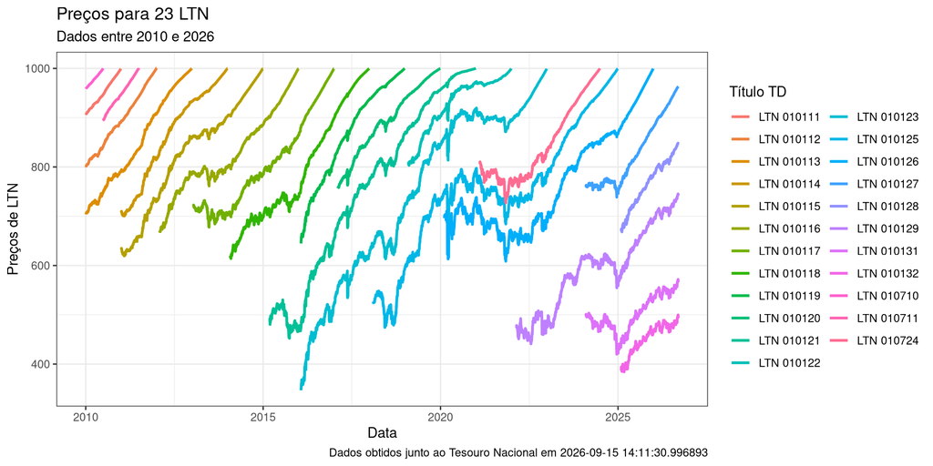

## Taxas Anuais do Tesouro Prefixado sem cupons

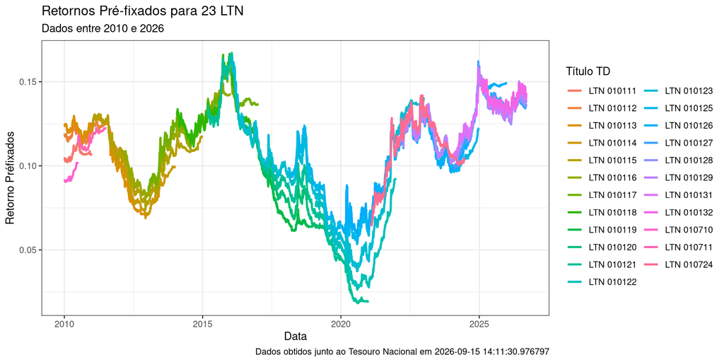

## Taxas do Tesouro X SELIc

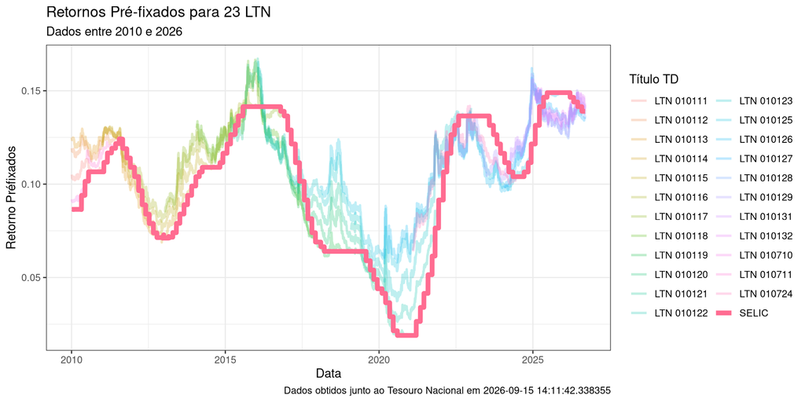

## Performance do Tesouro Direto

10 **Melhores** Retornos do Tesouro Direto

Dados entre 2005 e 2026

| asset_code | first_date | total_return | yearly_return |
| --- | --- | --- | --- |
| LTN 010123 | 2016-01-26 | 188.2643% | 16.5091% |
| LFT 180608 | 2005-01-03 | 62.6477% | 15.1188% |
| LFT 180309 | 2005-01-03 | 79.3661% | 14.9145% |
| NTN-B Principal 150515 | 2005-07-18 | 289.4030% | 14.8357% |
| NTN-B Principal 150824 | 2005-07-18 | 1 300.2693% | 14.8285% |
| LFT 010329 | 2023-01-09 | 58.4449% | 13.3137% |
| LTN 010121 | 2015-03-10 | 105.3055% | 13.1710% |
| LTN 010118 | 2014-01-27 | 61.2673% | 12.9731% |
| LFT 010326 | 2023-01-09 | 46.3903% | 12.9176% |
| LFT 170310 | 2005-11-16 | 68.2809% | 12.7675% |

10 **Piores** Retornos do Tesouro Direto

Dados entre 2005 e 2026

| asset_code | first_date | total_return | yearly_return |
| --- | --- | --- | --- |
| LTN 010125 | 2018-02-07 | 89.6912% | 9.7248% |
| NTN-B Principal 150519 | 2013-01-14 | 72.8589% | 9.0288% |
| LTN 010117 | 2013-01-14 | 38.5029% | 8.5693% |
| NTN-B Principal 150826 | 2020-02-10 | 70.1556% | 8.5045% |
| LFT 010321 | 2015-03-10 | 61.6114% | 8.3689% |
| LFT 010325 | 2019-02-01 | 62.6512% | 8.3302% |
| LFT 010323 | 2017-02-08 | 51.0571% | 7.0467% |
| NTN-B Principal 150545 | 2017-02-08 | 85.3087% | 6.6345% |
| LTN 010724 | 2021-02-08 | 23.2848% | 6.3766% |
| LTN 010126 | 2020-02-10 | 43.5936% | 6.3350% |

# Debêntures

## O Mercado de Debêntures

- Uma empresa pode obter dinheiro para financiar suas operações através da emissão de dívidas chamadas debêntures
- O mercado secundário de debêntures no Brasil ainda é pouco líquido
- Quem comprar um volume alto de debêntures, provavelmente terá que ficar com o título até sua maturidade
- O risco das debêntures é sempre maior que o risco de títulos públicos, portanto elas oferecem melhor retorno

## Componentes de uma Debênture

- Termos da obrigação (preço, prazo, etc)
- Garantia (em caso de default)
- Preferência (em caso de default)
- Cláusula de resgate antecipado
- Cláusulas protetoras (e.g. Empresa emissora de debênture não pode tomar mais de X emprestado dentro de 5 anos)

## Risco das Obrigações

- Classificações de acordo com os quatros C:
  - Caráter
  - Capacidade
  - Colaterais
  - Covenants (termos e condições)
- Classificações (agências Moodys and S&P)
  - AAA/Aaa
  - AA
  - A
  - BBB
  - BB
  - CC

## Quadro de classificação

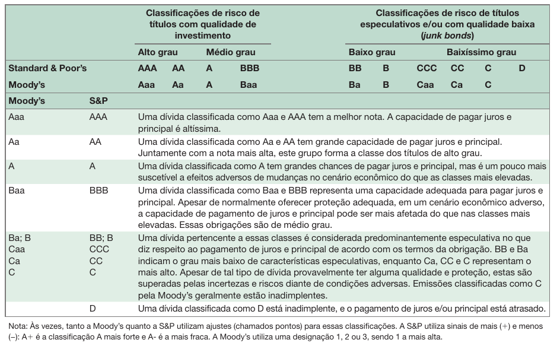

Extraído de Ross et al. (2022), página 209

## Exemplo de Debênture

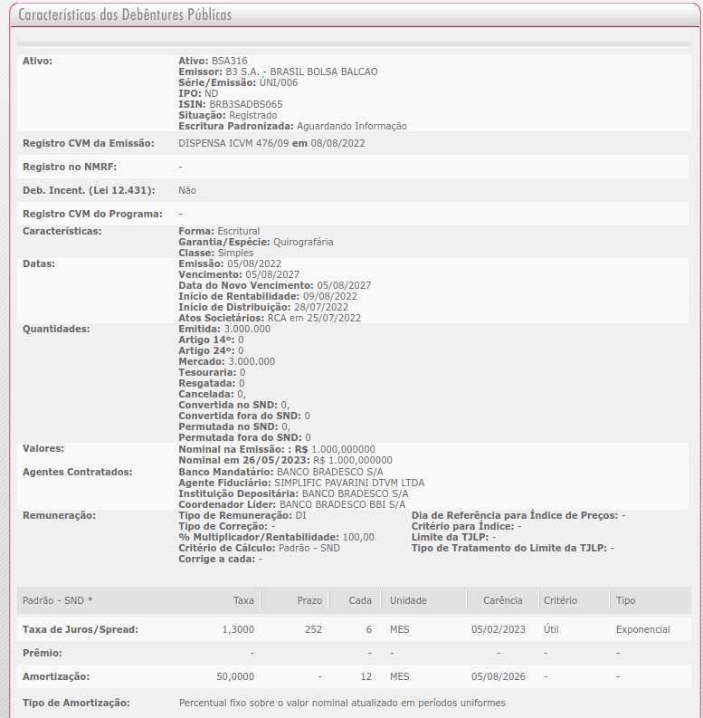

Extraído de [www.debentures.com.br](http://www.debentures.com.br/exploreosnd/consultaadados/emissoesdedebentures/caracteristicas_d.asp?tip_deb=publicas&selecao=BSA316)

[Lista de Debêntures disponíveis](https://www.b3.com.br/pt_br/produtos-e-servicos/negociacao/renda-fixa/debentures/debentures-listados/)

## Referências

Ross, Stephen, Randolph Westerfield, Bradford Jordan, et al. 2022. *Fundamentos de Administração Financeira*. Bookman Editora.